# Assignment 8

SiruiZHAO

2023-03-08

#### [My GitHub](https://github.com/siruiZHAO/Metabarcoding-Community-Ecology.git)

#### Load Library

```r
library(dplyr)
library(ggplot2)
library(ggpubr)
library(ape)
library(ggtree)
library(reshape2)
library(vegan)
```

#### Import/inspect Data

```r
#data import
mydata <- read.csv("./Data/FloristicSurvey.csv")

#check data
str(mydata)
```

```
## 'data.frame':    30 obs. of  44 variables:
##  $ Quadrate                 : chr  "7o3" "7o1" "7o2" "7i3" ...
##  $ Population               : int  7 7 7 7 7 7 3 3 3 3 ...
##  $ Location                 : chr  "o" "o" "o" "i" ...
##  $ Rosettes                 : int  0 0 0 14 3 0 14 0 0 0 ...
##  $ Bolting                  : int  0 0 0 8 18 3 3 12 26 0 ...
##  $ Budding                  : int  0 0 0 157 184 122 11 23 19 0 ...
##  $ Bud_Flw                  : int  0 0 0 0 0 0 0 0 0 0 ...
##  $ Flower                   : int  0 0 0 0 0 0 0 0 0 0 ...
##  $ Flw_Sil                  : int  0 0 0 0 0 0 0 0 0 0 ...
##  $ Sillique                 : int  0 0 0 0 0 0 0 0 0 0 ...
##  $ Claytonia_virginiana     : int  38 29 57 22 54 44 0 0 0 0 ...
##  $ Anemone_hepatica         : int  8 7 3 0 0 0 0 0 0 0 ...
##  $ Grass_tuft               : int  14 22 6 10 3 0 0 0 0 0 ...
##  $ Trillium_grandifolium    : int  9 30 8 0 0 0 0 0 0 0 ...
```

[output cut: 30 more lines]

```r
mydata$Population <- as.character(mydata$Population)
```

#### Analysis

##### Data Selection

```r
#how the communities of plants differ across sample locations
#select species and make Quadrate as row names
data1 <- mydata %>%
  select(11:44)
row.names(data1) <- mydata$Quadrate
```

##### Binary Distance Matrix

```r
BinDat<-data1
for(row in 1:nrow(data1)){
  for(col in 1:ncol(data1)){
    if(BinDat[row,col]>0){
      BinDat[row,col]<-1
    }
  }
}
head(BinDat)
```

```
##     Claytonia_virginiana Anemone_hepatica Grass_tuft Trillium_grandifolium
## 7o3                    1                1          1                     1
## 7o1                    1                1          1                     1
## 7o2                    1                1          1                     1
## 7i3                    1                0          1                     0
## 7i2                    1                0          1                     0
## 7i1                    1                0          0                     0
##     Erythronium.trout.lily. Acer_saccharum Dicentra_cucularia Bloodroot
## 7o3                       1              1                  0         0
## 7o1                       1              1                  1         1
## 7o2                       1              1                  1         0
## 7i3                       1              0                  0         0
## 7i2                       1              1                  0         1
## 7i1                       1              0                  0         0
##     Gallium_aparine Ulmus_americana Unknown_1 Unknown_2
## 7o3               0               0         0         0
## 7o1               1               1         1         0
## 7o2               1               0         0         0
## 7i3               1               1         0         1
## 7i2               1               1         0         1
## 7i1               1               1         0         1
##     Unknown_3.rannunculaceae. Unknown_4 Dryopteris_marginalis Ostrich_fern
## 7o3                         0         0                     0            0
## 7o1                         0         0                     0            0
## 7o2                         0         0                     0            0
## 7i3                         0         0                     0            0
## 7i2                         0         0                     0            0
## 7i1                         0         0                     0            0
##     Plantago_lanceolata Violet Rhamnus_frangula Raspberry Unknown_5 Unknown_6
## 7o3                   0      0                0         0         0         0
## 7o1                   0      0                0         0         0         0
## 7o2                   0      0                0         0         0         0
## 7i3                   0      0                0         0         0         0
## 7i2                   0      0                0         0         0         0
## 7i1                   0      0                0         0         0         0
##     Solidago_canadensis Unknown_7 Dandelion grass viccia_cracca herb_robert
## 7o3                   0         0         0     0             0           0
## 7o1                   0         0         0     0             0           0
## 7o2                   0         0         0     0             0           0
## 7i3                   0         0         0     0             0           0
## 7i2                   0         0         0     0             0           0
## 7i1                   0         0         0     0             0           0
##     thorny_ash rhamnus_cathartica rhubarb Unknown_8 Unknown_9
## 7o3          0                  0       0         0         0
## 7o1          0                  0       0         0         0
## 7o2          0                  0       0         0         0
## 7i3          0                  0       0         0         0
## 7i2          0                  0       0         0         0
## 7i1          0                  0       0         0         0
##     maianthenum_racemosum
## 7o3                     0
## 7o1                     0
## 7o2                     0
## 7i3                     0
## 7i2                     0
## 7i1                     0
```

##### Neighbor-Joining

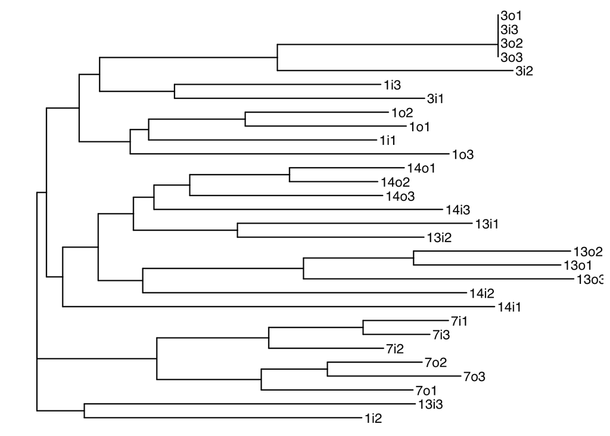

```r
#pairwise distance of the binary matrix
BinDist <- dist(BinDat, method = 'binary')

#NJ tree
tree <- nj(BinDist)
ggtree(tree, layout = "rectangular") %<+% mydata +
  geom_tiplab()
```

##### Bray-Curtis dissimilarity

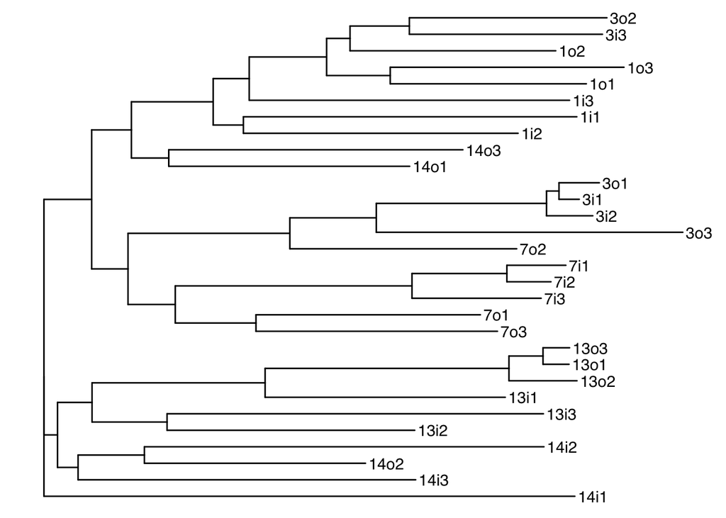

```r
Dat_dist <- vegdist(data1, method = "bray", binary = F)
Tree_2 <- nj(Dat_dist)
ggtree(Tree_2, layout = "rectangular") %<+% mydata +
  geom_tiplab()
```

These two tree topology have some differences. And not like the first one, the one in the Bray-Curtis section organize the tree based on how different the group are from each other. So, we would like to use the second one in our analysis.

##### NJ tree Group by garlic presence

```r
#point out the location and population of garlic mustard
present <- gsub(".*([o|i]).*", "\\1", Tree_2$tip.label)
population <- gsub("(.*)[o|i].*", "\\1", Tree_2$tip.label)

#group tip labels
PreGroups <- split(Tree_2$tip.label, present)
PopuGroups <- split(Tree_2$tip.label, population)

#apply group to plot
PreDTcol <- groupOTU(Tree_2, PreGroups)
PopuDTcol <- groupOTU(Tree_2, PopuGroups)
```

[figure not shown]

```r
#plot
P1 <- ggtree(PreDTcol, layout = "rectangular", aes(color = group)) +
  geom_tiplab(size = 2) +
  scale_color_manual(name = "Garlic Mustard Patches",
                     values = rainbow(2),
                     labels = c("Inside", "Outside"))
P2 <- ggtree(PopuDTcol, layout = "rectangular", aes(color = group)) +
  geom_tiplab(size = 2) +
  scale_color_manual(name = "Population",
                     values = rainbow(5),
                     labels = c("1", "3", "7", "13", "14"))
figure1 <- ggarrange(P1, P2, labels = c("A", "B"), ncol = 1, nrow = 2)
figure1
```

Figure 1: Neighbor-Joining Tree that clusters smples based on the similarity of species abundance. A) Different colors represent whether quadrate measurements are taken inside (red) or outside (blue) of garlic mustard patches. B) Different colors represent a specific sampling location at QUBS, determined by presence of garlic mustard nearby.

##### NMDS analysis

```r
set.seed(20)
NMDSdat <- metaMDS(Dat_dist, k = 2, trymax = 100)
```

```
## *** Best solution repeated 3 times
```

```r
#create data for plotting
PDat <- data.frame(NMDS1 = NMDSdat$points[,1],
                   NMDS2 = NMDSdat$points[,2],
                   Quadrate = row.names(data1))

#add species labels
PDat <- merge(PDat, mydata, by = "Quadrate", all.x = T, all.y = F)
```

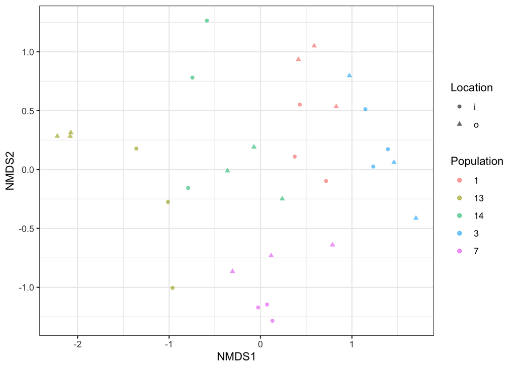

```r
#plot
qplot(x = NMDS1, y = NMDS2, color = Population, shape = Location,
      alpha = I(0.6), data = PDat) +
  theme_bw()
```

Figure 2: Non_Metric Multidimensional Scaling to visualize similarity and differences among species abundance.

#### Report

Garlic mustard is an invasive plant in ON, CA. it can reduce the biodiversity and aesthetic value of natural areas. In this study, the data collected from 5 different locations (Populations) at QUBS, which were determined by the presence of garlic mustard nearby, and grouped by the location, which indicates whether Quadrate measurements are taken ‘i’ for ‘inside’ or ‘o’ for ‘outside’ of garlic mustard patches.